# Proposition for Lead Scoring System and Business Growth

*- Case Study for a Fictitious Online Courses Company*  
By Huan Deng

`Table of Contents`  
**1 Data Cleaning**  
1.1 Data Cleaning Strategies  
1.2 Result  
**2 Data Exploration**  
2.1 Overview  
2.2 Response Variable  
2.3 Numerical Variables  
2.4 Charater Variables  
2.4 Correlation Check  
**3 Data Processing**  
3.1 One-Hot Encoding  
3.2 Splitting Dataset into Training and Test Set  
3.3 Feature Scaling  
**4 Data Modeling**  
4.1 CatBoost  
4.11 Model Building  
4.12 K-Fold Cross Validation  
4.2 Random Forest  
4.21 Grid Search  
4.22 Model Building  
4.23 K-Fold Cross Validation  
4.3 XGBoost  
4.31 Grid Search  
4.32 Model Building  
4.33 K-Fold Cross Validation  
4.4 Logistic Regression  
4.41-4.44 1st~4th Try  
4.45 5th Try - Best Model  
4.46 Model Implications  
**5 Lead Scoring System**

# 1. Data Cleaning

*I used R to clean the data. Please refer to R file if you would like to see more details.*

```python
import pandas as pd
import numpy as np
import matplotlib.pyplot as plt
import seaborn as sns
%matplotlib inline
```

The unprocessed raw data looks like below:

```python
uncleaned = pd.read_csv('Data for Case Study Data Science Online Courses.csv')
```

```python
def overview(uncleaned):
    overview = pd.DataFrame(uncleaned.dtypes, columns=['Data Types'])
    overview = overview.reset_index()
    overview['Unique Values'] = uncleaned.nunique().values
    overview['Missing Values'] = uncleaned.isnull().sum().values

    return overview

overview(uncleaned)
```

|  | index | Data Types | Unique Values | Missing Values |
| --- | --- | --- | --- | --- |
| 0 | Prospect ID | object | 9240 | 0 |
| 1 | Lead Number | int64 | 9240 | 0 |
| 2 | Lead Origin | object | 5 | 0 |
| 3 | Lead Source | object | 21 | 36 |
| 4 | Do Not Email | object | 2 | 0 |
| 5 | Do Not Call | object | 2 | 0 |
| 6 | Converted | int64 | 2 | 0 |
| 7 | TotalVisits | float64 | 41 | 137 |
| 8 | Total Time Spent on Website | int64 | 1731 | 0 |
| 9 | Page Views Per Visit | float64 | 114 | 137 |
| 10 | Last Activity | object | 17 | 103 |
| 11 | Country | object | 38 | 2461 |
| 12 | Specialization | object | 19 | 1438 |
| 13 | How did you hear about Data Science Online Cou... | object | 10 | 2207 |
| 14 | What is your current occupation | object | 6 | 2690 |
| 15 | What matters most to you in choosing a course | object | 3 | 2709 |
| 16 | Search | object | 2 | 0 |
| 17 | Magazine | object | 1 | 0 |
| 18 | Newspaper Article | object | 2 | 0 |
| 19 | Data Science Online Courses Forums | object | 2 | 0 |
| 20 | Newspaper | object | 2 | 0 |
| 21 | Digital Advertisement | object | 2 | 0 |
| 22 | Through Recommendations | object | 2 | 0 |
| 23 | Receive More Updates About Our Courses | object | 1 | 0 |
| 24 | Tags | object | 26 | 3353 |
| 25 | Lead Quality | object | 5 | 4767 |
| 26 | Update me on Data Science Content | object | 1 | 0 |
| 27 | Get updates on DM Content | object | 1 | 0 |
| 28 | Lead Profile | object | 6 | 2709 |
| 29 | City | object | 7 | 1420 |
| 30 | Asymmetrique Activity Index | object | 3 | 4218 |
| 31 | Asymmetrique Profile Index | object | 3 | 4218 |
| 32 | Asymmetrique Activity Score | float64 | 12 | 4218 |
| 33 | Asymmetrique Profile Score | float64 | 10 | 4218 |
| 34 | I agree to pay the amount through check or cre... | object | 1 | 0 |
| 35 | A free copy of Mastering The Case Study | object | 2 | 0 |
| 36 | Last Notable Activity | object | 16 | 0 |

## 1.1 Data Cleaning Strategies

**Characters:**

- Put the new label for labels with few results so as to avoid data shift between train and test data.
- Replace NA values with "Others".
- Replace "Select" with "Others".
- Convert variable to factor.

**Numerical Variables:**

- Replace NA values with mean variable
- Remove outliers and fill them with 95% quantile value.

**Other Strategy:**

- Change the long variable name into short one to enhance readability

## 1.2 Result

```python
data = pd.read_csv('Cleaned_Data Science Online Courses.csv', index_col = 0)
```

```python
overview(data)
```

|  | index | Data Types | Unique Values | Missing Values |
| --- | --- | --- | --- | --- |
| 0 | Lead Origin | object | 4 | 0 |
| 1 | Lead Source | object | 22 | 0 |
| 2 | Do Not Email | int64 | 2 | 0 |
| 3 | Do Not Call | int64 | 2 | 0 |
| 4 | Converted | int64 | 2 | 0 |
| 5 | TotalVisits | float64 | 12 | 0 |
| 6 | TotalTime | int64 | 1463 | 0 |
| 7 | PPV | float64 | 92 | 0 |
| 8 | Last Activity | object | 18 | 0 |
| 9 | Country | object | 39 | 0 |
| 10 | Specialization | object | 19 | 0 |
| 11 | HowHear | object | 9 | 0 |
| 12 | CurrentOccupation | object | 7 | 0 |
| 13 | WhatMatters | object | 4 | 0 |
| 14 | Search | int64 | 2 | 0 |
| 15 | Magazine | int64 | 1 | 0 |
| 16 | Newspaper Article | int64 | 2 | 0 |
| 17 | DSForums | int64 | 2 | 0 |
| 18 | Newspaper | int64 | 2 | 0 |
| 19 | Digital Advertisement | int64 | 2 | 0 |
| 20 | Through Recommendations | int64 | 2 | 0 |
| 21 | ReceiveUpdates | int64 | 1 | 0 |
| 22 | Tags | object | 27 | 0 |
| 23 | Lead Quality | object | 6 | 0 |
| 24 | UpdateDScontent | int64 | 1 | 0 |
| 25 | UpdateDMcontent | int64 | 1 | 0 |
| 26 | Lead Profile | object | 7 | 0 |
| 27 | City | object | 6 | 0 |
| 28 | Asymmetrique Activity Index | object | 4 | 0 |
| 29 | Asymmetrique Profile Index | object | 4 | 0 |
| 30 | Asymmetrique Activity Score | float64 | 13 | 0 |
| 31 | Asymmetrique Profile Score | float64 | 11 | 0 |
| 32 | PayThrough | int64 | 1 | 0 |
| 33 | FreeCopy | int64 | 2 | 0 |
| 34 | LastNotableActivity | object | 16 | 0 |

We can see that there is no missing value after cleaning the data and all of the column names look good.

# 2. Data Exploration

*Business insights can be found in the report slides.*

**Strategies:**

- Create a crosstab of each feature and `Converted`
- Reduce redundancy by merging similar categories

## 2.1 Overview

```python
data.info()
```

```
<class 'pandas.core.frame.DataFrame'>
Int64Index: 9240 entries, 1 to 9240
Data columns (total 35 columns):
 #   Column                       Non-Null Count  Dtype
---  ------                       --------------  -----
 0   Lead Origin                  9240 non-null   object
 1   Lead Source                  9240 non-null   object
 2   Do Not Email                 9240 non-null   int64
 3   Do Not Call                  9240 non-null   int64
 4   Converted                    9240 non-null   int64
 5   TotalVisits                  9240 non-null   float64
 6   TotalTime                    9240 non-null   int64
 7   PPV                          9240 non-null   float64
 8   Last Activity                9240 non-null   object
 9   Country                      9240 non-null   object
```

[output cut: 27 more lines]

```python
data.describe()
```

|  | Do Not Email | Do Not Call | Converted | TotalVisits | TotalTime | PPV | Search | Magazine | Newspaper Article | DSForums | Newspaper | Digital Advertisement | Through Recommendations | ReceiveUpdates | UpdateDScontent | UpdateDMcontent | Asymmetrique Activity Score | Asymmetrique Profile Score | PayThrough | FreeCopy |
| --- | --- | --- | --- | --- | --- | --- | --- | --- | --- | --- | --- | --- | --- | --- | --- | --- | --- | --- | --- | --- |
| count | 9240.00 | 9240.00 | 9240.00 | 9240.00 | 9240.00 | 9240.00 | 9240.00 | 9240.00 | 9240.00 | 9240.00 | 9240.00 | 9240.00 | 9240.00 | 9240.00 | 9240.00 | 9240.00 | 9240.00 | 9240.00 | 9240.00 | 9240.00 |
| mean | 0.08 | 0.00 | 0.39 | 3.19 | 479.24 | 2.26 | 0.00 | 0.00 | 0.00 | 0.00 | 0.00 | 0.00 | 0.00 | 0.00 | 0.00 | 0.00 | 14.31 | 16.34 | 0.00 | 0.31 |
| std | 0.27 | 0.01 | 0.49 | 2.76 | 528.82 | 1.78 | 0.04 | 0.00 | 0.01 | 0.01 | 0.01 | 0.02 | 0.03 | 0.00 | 0.00 | 0.00 | 1.02 | 1.34 | 0.00 | 0.46 |
| min | 0.00 | 0.00 | 0.00 | 0.00 | 0.00 | 0.00 | 0.00 | 0.00 | 0.00 | 0.00 | 0.00 | 0.00 | 0.00 | 0.00 | 0.00 | 0.00 | 7.00 | 11.00 | 0.00 | 0.00 |
| 25% | 0.00 | 0.00 | 0.00 | 1.00 | 12.00 | 1.00 | 0.00 | 0.00 | 0.00 | 0.00 | 0.00 | 0.00 | 0.00 | 0.00 | 0.00 | 0.00 | 14.00 | 16.00 | 0.00 | 0.00 |
| 50% | 0.00 | 0.00 | 0.00 | 3.00 | 248.00 | 2.00 | 0.00 | 0.00 | 0.00 | 0.00 | 0.00 | 0.00 | 0.00 | 0.00 | 0.00 | 0.00 | 14.31 | 16.34 | 0.00 | 0.00 |
| 75% | 0.00 | 0.00 | 1.00 | 5.00 | 936.00 | 3.00 | 0.00 | 0.00 | 0.00 | 0.00 | 0.00 | 0.00 | 0.00 | 0.00 | 0.00 | 0.00 | 14.31 | 16.34 | 0.00 | 1.00 |
| max | 1.00 | 1.00 | 1.00 | 10.00 | 1562.00 | 6.00 | 1.00 | 0.00 | 1.00 | 1.00 | 1.00 | 1.00 | 1.00 | 0.00 | 0.00 | 0.00 | 18.00 | 20.00 | 0.00 | 1.00 |

```
array([[<matplotlib.axes._subplots.AxesSubplot object at 0x7f9fdf828fd0>,
      dtype=object)
```

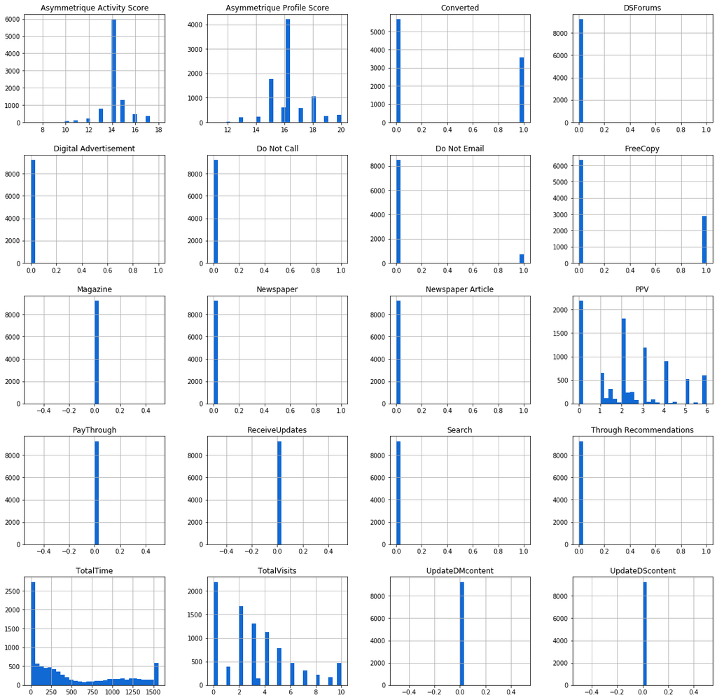

```python
data.hist(bins = 30, figsize = (20,20), color = '#1169D4')
```

```python
drop_list = ['DSForums', 'Digital Advertisement', 'Do Not Call', 'Do Not Email', 'Magazine', 'Newspaper',
            'Newspaper Article', 'PayThrough', 'ReceiveUpdates', 'Search', 'Through Recommendations', 'UpdateDScontent',
            'UpdateDMcontent']
data = data.drop(columns = drop_list)
```

**Asymmetrique Activity/Profile Index**

**Asymmetrique Activity/Profile Score**

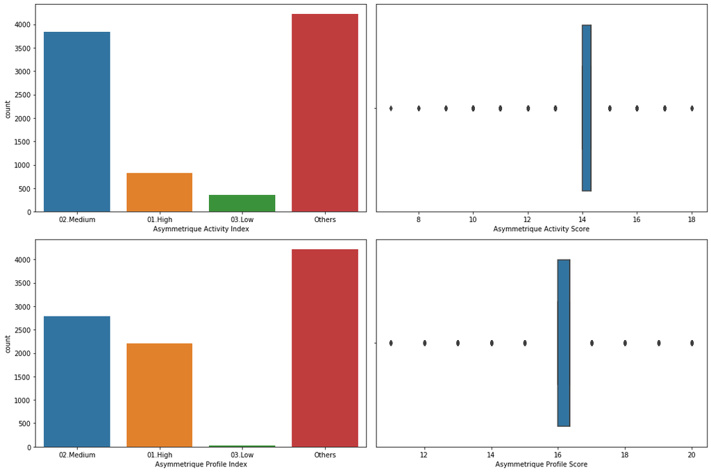

```python
fig, axs = plt.subplots(2,2, figsize = (15,10))
plt1 = sns.countplot(data['Asymmetrique Activity Index'], ax = axs[0,0])
plt2 = sns.boxplot(data['Asymmetrique Activity Score'], ax = axs[0,1])
plt3 = sns.countplot(data['Asymmetrique Profile Index'], ax = axs[1,0])
plt4 = sns.boxplot(data['Asymmetrique Profile Score'], ax = axs[1,1])
plt.tight_layout()
```

I decide to delete those values because:  
1) There are too much variation  
2) After Googling thoese index/score, I found these values are created by an Indian advertising agency but there is no documentation explaining their meaning and no further analysis can be made due to lack of background information.

```python
drop_list2 = ['Asymmetrique Activity Index','Asymmetrique Activity Score',
                  'Asymmetrique Profile Index','Asymmetrique Profile Score']
data = data.drop(columns = drop_list2)
```

## 2.2 Response Variable

```
Total = 9240
Number of leads who converted = 3561
Percentage of leads who converted = 38.53896103896104 %
Number of leads who did not convert = 5679
Percentage of leads who did not convert = 61.46103896103896 %
```

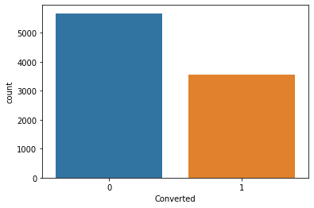

```python
converted  = data[data['Converted'] == 1]
nonconverted = data[data['Converted'] == 0]

print("Total =", len(data))

print("Number of leads who converted =", len(converted))
print("Percentage of leads who converted =", 1.*len(converted)/len(data)*100.0, "%")

print("Number of leads who did not convert =", len(nonconverted))
print("Percentage of leads who did not convert =", 1.*len(nonconverted)/len(data)*100.0, "%")

sns.countplot(data['Converted']);
```

## 2.3 Numerical Variables

### Total Visits

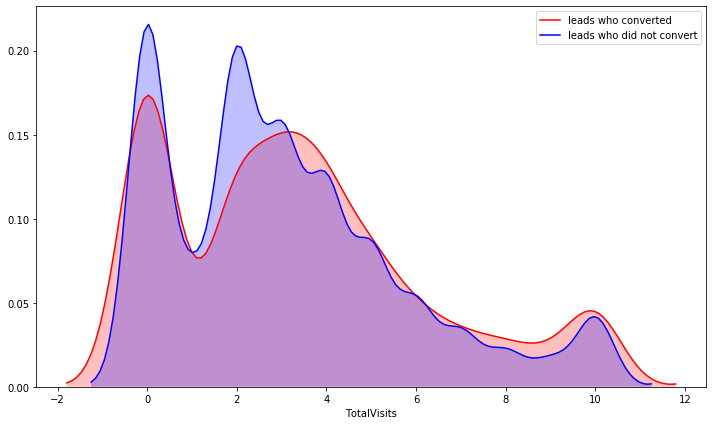

```python
# KDE describes the probability density at different values in a continuous variable.

plt.figure(figsize=(12,7))

sns.kdeplot(converted['TotalVisits'], label = 'leads who converted', shade = True, color = 'r')
sns.kdeplot(nonconverted['TotalVisits'], label = 'leads who did not convert', shade = True, color = 'b')

plt.xlabel('TotalVisits')
```

When the number of `Total visits` is less than 3, there are more leads who did not convert than converted.

### Total Time

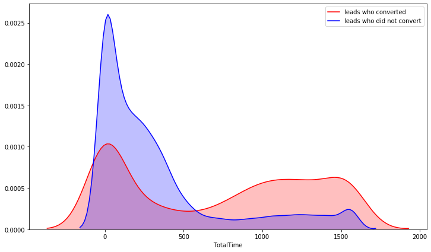

```python
plt.figure(figsize=(12,7))

sns.kdeplot(converted['TotalTime'], label = 'leads who converted', shade = True, color = 'r')
sns.kdeplot(nonconverted['TotalTime'], label = 'leads who did not convert', shade = True, color = 'b')

plt.xlabel('TotalTime')
```

When `Total Time` is less than 600, there are more leads who did not convert. However, when it is more than 600, leads tend to convert.

### Pages per visits

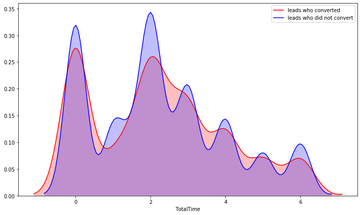

```python
plt.figure(figsize=(12,7))

sns.kdeplot(converted['PPV'], label = 'leads who converted', shade = True, color = 'r')
sns.kdeplot(nonconverted['PPV'], label = 'leads who did not convert', shade = True, color = 'b')

plt.xlabel('TotalTime')
```

There seems to be little difference between leads who converted and those who did not convert in various `Total Time.`

## 2.4 Character Variables

```python
def count(df, v1, v2):
    ctr = df[[v1, v2]].groupby(v1, as_index=False).mean().sort_values(v2, ascending=False)
    count = df[[v1, v2]].groupby(v1, as_index=False).count().sort_values(v2, ascending=False)
    merge = count.merge(ctr, on=v1, how='left')
    merge.columns=[v1, 'Count', 'Converted Rate(%)']
    return merge

def crosstab (df, features, target):
    """Plot the bar char of count by converted"""
    for feature in features:
        pd.crosstab(df[feature],df[target]).plot(kind='barh', figsize=(13,8), stacked=True)
        plt.title('Number of '+ feature+' by '+ target)
        plt.xlabel('Count')
        plt.ylabel(feature)
        # Display the table obove each chart
        return count(df, feature, target)
```

### Lead Origin

|  | Lead Origin | Count | Converted Rate(%) |
| --- | --- | --- | --- |
| 0 | Landing Page Submission | 4886 | 0.36 |
| 1 | API | 3580 | 0.31 |
| 2 | Lead Add Form | 718 | 0.92 |
| 3 | Lead Import&Quick Add Form | 56 | 0.25 |

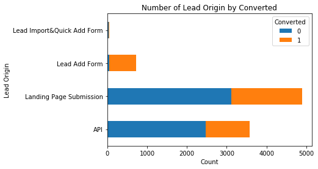

```python
crosstab(data, ['Lead Origin'], 'Converted')
```

### Lead Source

[output not shown]

[figure not shown]

```python
crosstab(data, ['Lead Source'], 'Converted')
```

```python
# There are google and Google so we need to fix the spelling issue
data.loc[data['Lead Source'] == 'google', 'Lead Source'] = 'Google'

# Put the new label for labels with few results so as to avoid data shift between train
# and test data.
data.loc[data['Lead Source'] == 'bing', 'Lead Source'] = 'Others'
data.loc[data['Lead Source'] == 'Click2call', 'Lead Source'] = 'Others'
data.loc[data['Lead Source'] == 'Press_Release', 'Lead Source'] = 'Others'
data.loc[data['Lead Source'] == 'Social Media', 'Lead Source'] = 'Others'
data.loc[data['Lead Source'] == 'Live Chat', 'Lead Source'] = 'Others'
data.loc[data['Lead Source'] == 'WeLearn', 'Lead Source'] = 'Others'
data.loc[data['Lead Source'] == 'Pay per Click Ads', 'Lead Source'] = 'Others'
data.loc[data['Lead Source'] == 'NC_EDM', 'Lead Source'] = 'Others'
data.loc[data['Lead Source'] == 'blog', 'Lead Source'] = 'Others'
data.loc[data['Lead Source'] == 'testone', 'Lead Source'] = 'Others'
data.loc[data['Lead Source'] == 'welearnblog_Home', 'Lead Source'] = 'Others'
data.loc[data['Lead Source'] == 'youtubechannel', 'Lead Source'] = 'Others'
```

|  | Lead Source | Count | Converted Rate(%) |
| --- | --- | --- | --- |
| 0 | Google | 2873 | 0.40 |
| 1 | Direct Traffic | 2543 | 0.32 |
| 2 | Olark Chat | 1755 | 0.26 |
| 3 | Organic Search | 1154 | 0.38 |
| 4 | Reference | 534 | 0.92 |
| 5 | Welingak Website | 142 | 0.99 |
| 6 | Referral Sites | 125 | 0.25 |
| 7 | Others | 59 | 0.64 |
| 8 | Facebook | 55 | 0.24 |

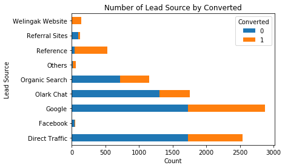

```python
crosstab(data, ['Lead Source'], 'Converted')
```

### Last Activity

|  | Last Activity | Count | Converted Rate(%) |
| --- | --- | --- | --- |
| 0 | Email Opened | 3437 | 0.36 |
| 1 | SMS Sent | 2745 | 0.63 |
| 2 | Olark Chat Conversation | 973 | 0.09 |
| 3 | Page Visited on Website | 640 | 0.24 |
| 4 | Converted to Lead | 428 | 0.13 |
| 5 | Email Bounced | 326 | 0.08 |
| 6 | Email Link Clicked | 267 | 0.27 |
| 7 | Form Submitted on Website | 116 | 0.24 |
| 8 | Others | 103 | 0.79 |
| 9 | Unreachable | 93 | 0.33 |
| 10 | Unsubscribed | 61 | 0.26 |
| 11 | Had a Phone Conversation | 30 | 0.73 |
| 12 | Approached upfront | 9 | 1.00 |
| 13 | View in browser link Clicked | 6 | 0.17 |
| 14 | Email Received | 2 | 1.00 |
| 15 | Email Marked Spam | 2 | 1.00 |
| 16 | Resubscribed to emails | 1 | 1.00 |
| 17 | Visited Booth in Tradeshow | 1 | 0.00 |

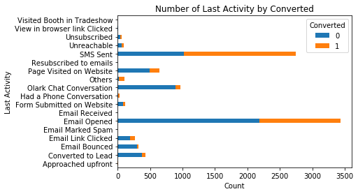

```python
crosstab(data, ['Last Activity'], 'Converted')
```

```python
data.loc[data['Last Activity'] == 'Had a Phone Conversation', 'Last Activity'] = 'Others'
data.loc[data['Last Activity'] == 'Approached upfront', 'Last Activity'] = 'Others'
data.loc[data['Last Activity'] == 'View in browser link Clicked', 'Last Activity'] = 'Others'
data.loc[data['Last Activity'] == 'Email Received', 'Last Activity'] = 'Others'
data.loc[data['Last Activity'] == 'Email Marked Spam', 'Last Activity'] = 'Others'
data.loc[data['Last Activity'] == 'Resubscribed to emails', 'Last Activity'] = 'Others'
data.loc[data['Last Activity'] == 'Visited Booth in Tradeshow', 'Last Activity'] = 'Others'
```

|  | Last Activity | Count | Converted Rate(%) |
| --- | --- | --- | --- |
| 0 | Email Opened | 3437 | 0.36 |
| 1 | SMS Sent | 2745 | 0.63 |
| 2 | Olark Chat Conversation | 973 | 0.09 |
| 3 | Page Visited on Website | 640 | 0.24 |
| 4 | Converted to Lead | 428 | 0.13 |
| 5 | Email Bounced | 326 | 0.08 |
| 6 | Email Link Clicked | 267 | 0.27 |
| 7 | Others | 154 | 0.77 |
| 8 | Form Submitted on Website | 116 | 0.24 |
| 9 | Unreachable | 93 | 0.33 |
| 10 | Unsubscribed | 61 | 0.26 |

[figure not shown]

```python
crosstab(data, ['Last Activity'], 'Converted')
```

### Country

|  | Country | Count | Converted Rate(%) |
| --- | --- | --- | --- |
| 0 | India | 6492 | 0.37 |
| 1 | Others | 2461 | 0.44 |
| 2 | United States | 69 | 0.26 |
| 3 | United Arab Emirates | 53 | 0.38 |
| 4 | Singapore | 24 | 0.46 |
| 5 | Saudi Arabia | 21 | 0.19 |
| 6 | United Kingdom | 15 | 0.33 |
| 7 | Australia | 13 | 0.23 |
| 8 | Qatar | 10 | 0.10 |
| 9 | Hong Kong | 7 | 0.57 |
| 10 | Bahrain | 7 | 0.57 |
| 11 | Oman | 6 | 0.50 |
| 12 | France | 6 | 0.50 |
| 13 | unknown | 5 | 0.20 |
| 14 | South Africa | 4 | 0.25 |
| 15 | Germany | 4 | 0.25 |
| 16 | Kuwait | 4 | 0.00 |
| 17 | Canada | 4 | 0.00 |
| 18 | Nigeria | 4 | 0.00 |
| 19 | Sweden | 3 | 0.33 |
| 20 | Uganda | 2 | 0.00 |
| 21 | Philippines | 2 | 0.00 |
| 22 | Asia/Pacific Region | 2 | 0.50 |
| 23 | Italy | 2 | 0.00 |
| 24 | Ghana | 2 | 0.00 |
| 25 | China | 2 | 0.00 |
| 26 | Belgium | 2 | 0.00 |
| 27 | Bangladesh | 2 | 0.50 |
| 28 | Netherlands | 2 | 0.50 |
| 29 | Malaysia | 1 | 0.00 |
| 30 | Liberia | 1 | 0.00 |
| 31 | Russia | 1 | 0.00 |
| 32 | Kenya | 1 | 0.00 |
| 33 | Indonesia | 1 | 0.00 |
| 34 | Sri Lanka | 1 | 0.00 |
| 35 | Switzerland | 1 | 0.00 |
| 36 | Tanzania | 1 | 0.00 |
| 37 | Denmark | 1 | 1.00 |
| 38 | Vietnam | 1 | 0.00 |

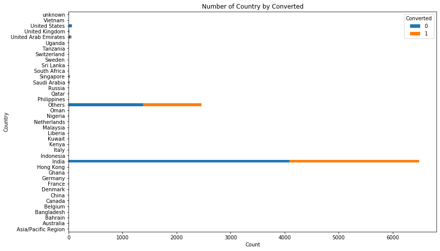

```python
crosstab(data, ['Country'], 'Converted')
```

### City

|  | City | Count | Converted Rate(%) |
| --- | --- | --- | --- |
| 0 | Other Cities | 4355 | 0.35 |
| 1 | Mumbai | 3222 | 0.41 |
| 2 | Thane & Outskirts | 752 | 0.45 |
| 3 | Other Cities of Maharashtra | 457 | 0.44 |
| 4 | Other Metro Cities | 380 | 0.41 |
| 5 | Tier II Cities | 74 | 0.34 |

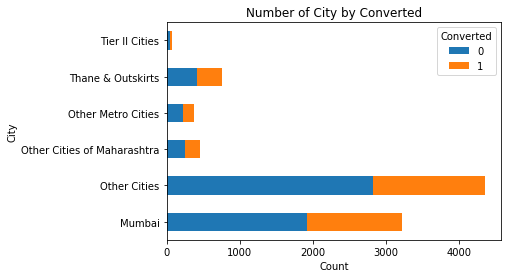

```python
crosstab(data, ['City'], 'Converted')
```

### Specialization

|  | Specialization | Count | Converted Rate(%) |
| --- | --- | --- | --- |
| 0 | Others | 3380 | 0.286686 |
| 1 | Finance Management | 976 | 0.446721 |
| 2 | Human Resource Management | 848 | 0.457547 |
| 3 | Marketing Management | 838 | 0.486874 |
| 4 | Operations Management | 503 | 0.473161 |
| 5 | Business Administration | 403 | 0.444169 |
| 6 | IT Projects Management | 366 | 0.382514 |
| 7 | Supply Chain Management | 349 | 0.432665 |
| 8 | Banking, Investment And Insurance | 338 | 0.494083 |
| 9 | Media and Advertising | 203 | 0.418719 |
| 10 | Travel and Tourism | 203 | 0.354680 |
| 11 | International Business | 178 | 0.359551 |
| 12 | Healthcare Management | 159 | 0.496855 |
| 13 | Hospitality Management | 114 | 0.421053 |
| 14 | E-Commence | 112 | 0.357143 |
| 15 | Retail Management | 100 | 0.340000 |
| 16 | Rural and Agribusiness | 73 | 0.424658 |
| 17 | E-Business | 57 | 0.368421 |
| 18 | Services Excellence | 40 | 0.275000 |

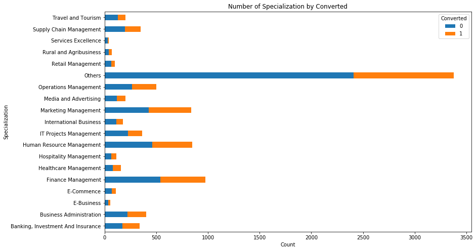

```python
crosstab(data, ['Specialization'], 'Converted')
```

```python
# Reduce redundancy by merging similar categories
data.loc[data['Specialization'] == 'Finance Management', 'Specialization'] = 'Finance'
data.loc[data['Specialization'] == 'Banking, Investment And Insurance', 'Specialization'] = 'Finance'

data.loc[data['Specialization'] == 'Human Resource Management', 'Specialization'] = 'Human Resource'

data.loc[data['Specialization'] == 'Operations Management', 'Specialization'] = 'Operations and Supply Chain'
data.loc[data['Specialization'] == 'Supply Chain Management', 'Specialization'] = 'Operations and Supply Chain'

data.loc[data['Specialization'] == 'Marketing Management', 'Specialization'] = 'Marketing'
data.loc[data['Specialization'] == 'Media and Advertising', 'Specialization'] = 'Marketing'

data.loc[data['Specialization'] == 'Business Administration', 'Specialization'] = 'Business'
data.loc[data['Specialization'] == 'International Business', 'Specialization'] = 'Business'
data.loc[data['Specialization'] == 'E-Commence', 'Specialization'] = 'Business'
data.loc[data['Specialization'] == 'E-Business', 'Specialization'] = 'Business'

data.loc[data['Specialization'] == 'Hospitality Management', 'Specialization'] = 'Tourism and Hospitality'
data.loc[data['Specialization'] == 'Services Excellence', 'Specialization'] = 'Tourism and Hospitality'
data.loc[data['Specialization'] == 'Travel and Tourism', 'Specialization'] = 'Tourism and Hospitality'

data.loc[data['Specialization'] == 'Healthcare Management', 'Specialization'] = 'Healthcare'

data.loc[data['Specialization'] == 'Retail Management', 'Specialization'] = 'Retail'

data.loc[data['Specialization'] == 'IT Projects Management', 'Specialization'] = 'IT'
```

|  | Specialization | Count | Converted Rate(%) |
| --- | --- | --- | --- |
| 0 | Others | 3380 | 0.286686 |
| 1 | Finance | 1314 | 0.458904 |
| 2 | Marketing | 1041 | 0.473583 |
| 3 | Operations and Supply Chain | 852 | 0.456573 |
| 4 | Human Resource | 848 | 0.457547 |
| 5 | Business | 750 | 0.405333 |
| 6 | IT | 366 | 0.382514 |
| 7 | Tourism and Hospitality | 357 | 0.366947 |
| 8 | Healthcare | 159 | 0.496855 |
| 9 | Retail | 100 | 0.340000 |
| 10 | Rural and Agribusiness | 73 | 0.424658 |

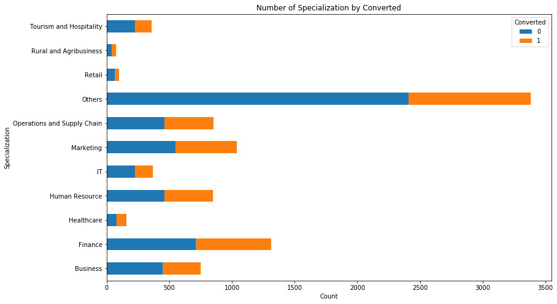

```python
crosstab(data, ['Specialization'], 'Converted')
```

### How did you hear about Data Science Online Courses

|  | HowHear | Count | Converted Rate(%) |
| --- | --- | --- | --- |
| 0 | Other | 7436 | 0.38 |
| 1 | Online Search | 808 | 0.42 |
| 2 | Word Of Mouth | 348 | 0.44 |
| 3 | Student of SomeSchool | 310 | 0.46 |
| 4 | Multiple Sources | 152 | 0.37 |
| 5 | Advertisements | 70 | 0.46 |
| 6 | Social Media | 67 | 0.42 |
| 7 | Email | 26 | 0.50 |
| 8 | SMS | 23 | 0.22 |

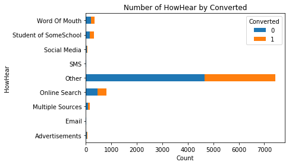

```python
crosstab(data, ['HowHear'], 'Converted')
```

```python
# Reduce redundancy by merging similar categories
data.loc[data['HowHear'] == 'Student of SomeSchool', 'HowHear'] = 'Word Of Mouth'
data.loc[data['HowHear'] == 'Other', 'HowHear'] = 'Others'
```

|  | HowHear | Count | Converted Rate(%) |
| --- | --- | --- | --- |
| 0 | Others | 7436 | 0.38 |
| 1 | Online Search | 808 | 0.42 |
| 2 | Word Of Mouth | 658 | 0.45 |
| 3 | Multiple Sources | 152 | 0.37 |
| 4 | Advertisements | 70 | 0.46 |
| 5 | Social Media | 67 | 0.42 |
| 6 | Email | 26 | 0.50 |
| 7 | SMS | 23 | 0.22 |

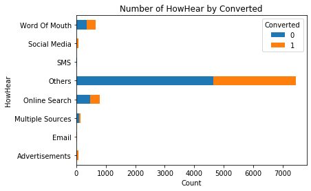

```python
crosstab(data, ['HowHear'], 'Converted')
```

### What is your current occupation?

|  | CurrentOccupation | Count | Converted Rate(%) |
| --- | --- | --- | --- |
| 0 | Unemployed | 5600 | 0.44 |
| 1 | Others | 2690 | 0.14 |
| 2 | Working Professional | 706 | 0.92 |
| 3 | Student | 210 | 0.37 |
| 4 | Other | 16 | 0.62 |
| 5 | Housewife | 10 | 1.00 |
| 6 | Businessman | 8 | 0.62 |

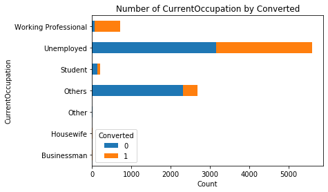

```python
crosstab(data, ['CurrentOccupation'], 'Converted')
```

```python
data.loc[data['CurrentOccupation'] == 'Other', 'CurrentOccupation'] = 'Others'
data.loc[data['CurrentOccupation'] == 'Businessman', 'CurrentOccupation'] = 'Working Professional'
data.loc[data['CurrentOccupation'] == 'Housewife', 'CurrentOccupation'] = 'Unemployed'
```

|  | CurrentOccupation | Count | Converted Rate(%) |
| --- | --- | --- | --- |
| 0 | Unemployed | 5610 | 0.44 |
| 1 | Others | 2706 | 0.14 |
| 2 | Working Professional | 714 | 0.91 |
| 3 | Student | 210 | 0.37 |

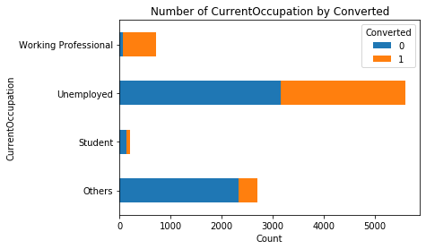

```python
crosstab(data, ['CurrentOccupation'], 'Converted')
```

### What matters most to you in choosing this course

|  | WhatMatters | Count | Converted Rate(%) |
| --- | --- | --- | --- |
| 0 | Better Career Prospects | 6528 | 0.49 |
| 1 | Others | 2709 | 0.14 |
| 2 | Flexibility & Convenience | 2 | 0.50 |
| 3 | Other | 1 | 0.00 |

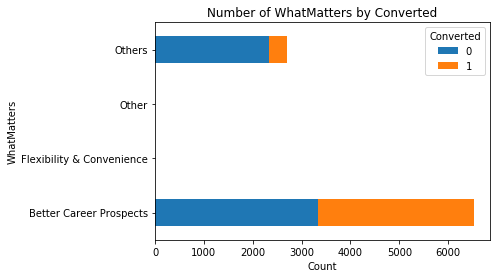

```python
crosstab(data, ['WhatMatters'], 'Converted')
```

```python
data.loc[data['WhatMatters'] == 'Flexibility & Convenience', 'WhatMatters'] = 'Others'
data.loc[data['WhatMatters'] == 'Other', 'WhatMatters'] = 'Others'
```

|  | WhatMatters | Count | Converted Rate(%) |
| --- | --- | --- | --- |
| 0 | Better Career Prospects | 6528 | 0.49 |
| 1 | Others | 2712 | 0.14 |

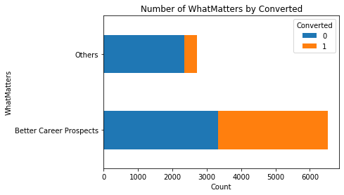

```python
crosstab(data, ['WhatMatters'], 'Converted')
```

### Tags

|  | Tags | Count | Converted Rate(%) |
| --- | --- | --- | --- |
| 0 | Others | 3353 | 0.249329 |
| 1 | Will revert after reading the email | 2072 | 0.968629 |
| 2 | Ringing | 1203 | 0.028263 |
| 3 | Interested in other courses | 513 | 0.025341 |
| 4 | Already a student | 465 | 0.006452 |
| 5 | Closed by Horizzon | 358 | 0.994413 |
| 6 | switched off | 240 | 0.016667 |
| 7 | Busy | 186 | 0.564516 |
| 8 | Lost to EINS | 175 | 0.977143 |
| 9 | Not doing further education | 145 | 0.006897 |
| 10 | Interested in full time MBA | 117 | 0.025641 |
| 11 | Graduation in progress | 111 | 0.063063 |
| 12 | invalid number | 83 | 0.012048 |
| 13 | Diploma holder (Not Eligible) | 63 | 0.015873 |
| 14 | wrong number given | 47 | 0.000000 |
| 15 | opp hangup | 33 | 0.090909 |
| 16 | number not provided | 27 | 0.000000 |
| 17 | in touch with EINS | 12 | 0.250000 |
| 18 | Lost to Others | 7 | 0.000000 |
| 19 | Still Thinking | 6 | 0.166667 |
| 20 | Want to take admission but has financial problems | 6 | 0.333333 |
| 21 | In confusion whether part time or DLP | 5 | 0.200000 |
| 22 | Interested in Next batch | 5 | 1.000000 |
| 23 | Lateral student | 3 | 1.000000 |
| 24 | University not recognized | 2 | 0.000000 |
| 25 | Shall take in the next coming month | 2 | 0.500000 |
| 26 | Recognition issue (DEC approval) | 1 | 0.000000 |

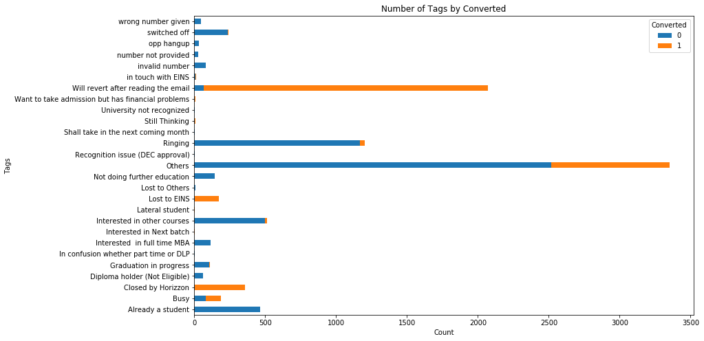

```python
crosstab(data, ['Tags'], 'Converted')
```

```python
# Reduce redundancy by merging similar categories
data.loc[data['Tags'] == 'wrong number given', 'Tags'] = 'invalid number or not provided'
data.loc[data['Tags'] == 'number not provided', 'Tags'] = 'invalid number or not provided'
data.loc[data['Tags'] == 'Already a student', 'Tags'] = 'Current Student'
data.loc[data['Tags'] == 'Graduation in progress', 'Tags'] = 'Current Student'
data.loc[data['Tags'] == 'Lateral student', 'Tags'] = 'Current Student'


data.loc[data['Tags'] == 'switched off', 'Tags'] = 'No Response'
data.loc[data['Tags'] == 'Busy', 'Tags'] = 'No Response'
data.loc[data['Tags'] == 'opp hangup', 'Tags'] = 'No Response'



data.loc[data['Tags'] == 'Interested in Next batch', 'Tags'] = 'Insterested'
data.loc[data['Tags'] == 'Shall take in the next coming month', 'Tags'] = 'Insterested'

data.loc[data['Tags'] == 'In confusion whether part time or DLP', 'Tags'] = 'Have Question'
data.loc[data['Tags'] == 'Want to take admission but has financial problems', 'Tags'] = 'Have Question'

data.loc[data['Tags'] == 'Recognition issue (DEC approval)', 'Tags'] = 'Have Question'
data.loc[data['Tags'] == 'University not recognized', 'Tags'] = 'Have Question'

data.loc[data['Tags'] == 'invalid number', 'Tags'] = 'invalid number or not provided'

data.loc[data['Tags'] == 'Interested in other courses', 'Tags'] = 'Insterested'
data.loc[data['Tags'] == 'Still Thinking', 'Tags'] = 'Insterested'
data.loc[data['Tags'] == 'Lost to EINS', 'Tags'] = 'Lost'
data.loc[data['Tags'] == 'Lost to Others', 'Tags'] = 'Lost'
```

|  | Tags | Count | Converted Rate(%) |
| --- | --- | --- | --- |
| 0 | Others | 3353 | 0.249329 |
| 1 | Will revert after reading the email | 2072 | 0.968629 |
| 2 | Ringing | 1203 | 0.028263 |
| 3 | Current Student | 579 | 0.022453 |
| 4 | Insterested | 526 | 0.038023 |
| 5 | No Response | 459 | 0.244009 |
| 6 | Closed by Horizzon | 358 | 0.994413 |
| 7 | Lost | 182 | 0.939560 |
| 8 | invalid number or not provided | 157 | 0.006369 |
| 9 | Not doing further education | 145 | 0.006897 |
| 10 | Interested in full time MBA | 117 | 0.025641 |
| 11 | Diploma holder (Not Eligible) | 63 | 0.015873 |
| 12 | Have Question | 14 | 0.214286 |
| 13 | in touch with EINS | 12 | 0.250000 |

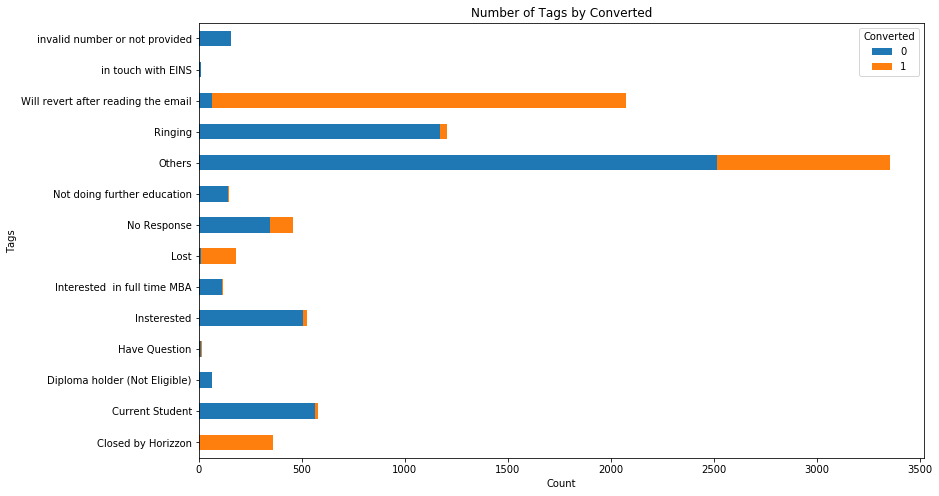

```python
crosstab(data, ['Tags'], 'Converted')
```

### Lead Quality

|  | Lead Quality | Count | Converted Rate(%) |
| --- | --- | --- | --- |
| 0 | Others | 4767 | 0.21 |
| 1 | Might be | 1560 | 0.76 |
| 2 | Not Sure | 1092 | 0.24 |
| 3 | High in Relevance | 637 | 0.95 |
| 4 | Worst | 601 | 0.02 |
| 5 | Low in Relevance | 583 | 0.82 |

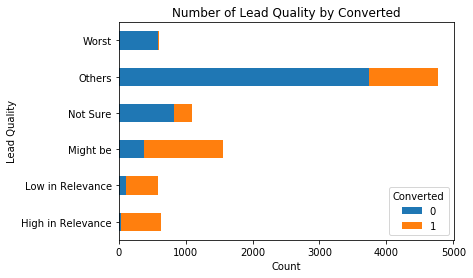

```python
crosstab(data, ['Lead Quality'], 'Converted')
```

### Lead Profile

|  | Lead Profile | Count | Converted Rate(%) |
| --- | --- | --- | --- |
| 0 | Select | 4146 | 0.41 |
| 1 | Others | 2709 | 0.14 |
| 2 | Potential Lead | 1613 | 0.79 |
| 3 | Other Leads | 487 | 0.37 |
| 4 | Student of SomeSchool | 241 | 0.04 |
| 5 | Lateral Student | 24 | 0.96 |
| 6 | Dual Specialization Student | 20 | 1.00 |

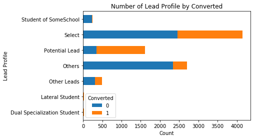

```python
crosstab(data, ['Lead Profile'], 'Converted')
```

```python
data.loc[data['Lead Profile'] == 'Select', 'Lead Profile'] = 'Others'
data.loc[data['Lead Profile'] == 'Other Leads', 'Lead Profile'] = 'Others'
```

|  | Lead Profile | Count | Converted Rate(%) |
| --- | --- | --- | --- |
| 0 | Others | 7342 | 0.31 |
| 1 | Potential Lead | 1613 | 0.79 |
| 2 | Student of SomeSchool | 241 | 0.04 |
| 3 | Lateral Student | 24 | 0.96 |
| 4 | Dual Specialization Student | 20 | 1.00 |

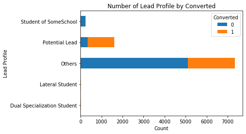

```python
crosstab(data, ['Lead Profile'], 'Converted')
```

### A free copy of Mastering The Case Study

|  | FreeCopy | Count | Converted Rate(%) |
| --- | --- | --- | --- |
| 0 | 0 | 6352 | 0.40 |
| 1 | 1 | 2888 | 0.36 |

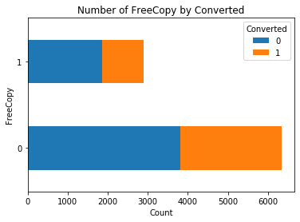

```python
crosstab(data, ['FreeCopy'], 'Converted')
```

### Last Notable Activity

|  | LastNotableActivity | Count | Converted Rate(%) |
| --- | --- | --- | --- |
| 0 | Modified | 3407 | 0.23 |
| 1 | Email Opened | 2827 | 0.37 |
| 2 | SMS Sent | 2172 | 0.69 |
| 3 | Page Visited on Website | 318 | 0.29 |
| 4 | Olark Chat Conversation | 183 | 0.14 |
| 5 | Email Link Clicked | 173 | 0.26 |
| 6 | Email Bounced | 60 | 0.15 |
| 7 | Unsubscribed | 47 | 0.30 |
| 8 | Unreachable | 32 | 0.69 |
| 9 | Had a Phone Conversation | 14 | 0.93 |
| 10 | Email Marked Spam | 2 | 1.00 |
| 11 | Approached upfront | 1 | 1.00 |
| 12 | Email Received | 1 | 1.00 |
| 13 | Form Submitted on Website | 1 | 0.00 |
| 14 | Resubscribed to emails | 1 | 1.00 |
| 15 | View in browser link Clicked | 1 | 0.00 |

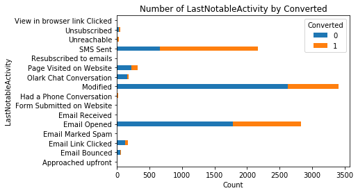

```python
crosstab(data, ['LastNotableActivity'], 'Converted')
```

```python
drop_list3 = ['LastNotableActivity', 'Country', 'WhatMatters', 'FreeCopy']
data = data.drop(columns = drop_list3)
```

```python
data.shape
```

[output not shown]

```python
data.info()
```

[output not shown]

[output cut: 19 more lines]

```python
# Store the newly cleaned data file
# data.to_csv('Newly Cleaned Data Science Online Courses.csv')
```

```python
data = pd.read_csv('Newly Cleaned Data Science Online Courses.csv', index_col = 0)
```

## 2.5 Correlation Check

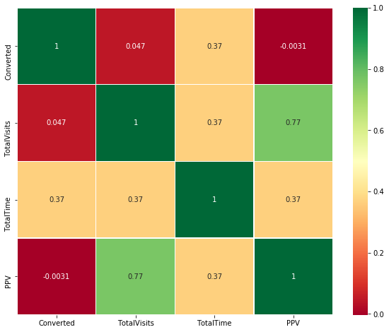

```python
sns.heatmap(data.corr(),annot=True,cmap='RdYlGn',linewidths=0.2)
fig=plt.gcf()
fig.set_size_inches(10,8)
plt.show()
```

Altough `TotalVisits` and `PPV` are highly correlated(0.77), I decide not to drop them now because they are very important metrics for further analysis.  
`TotalVisits` represent the exposure while `PPV` shows the enagement. `PPV` is particularly useful for online course website performance evaluation because visitors tend to make purchases when `PPV` is high.  
I will wait to see if there is overfitting problem.  
Actually in the later logistic regression, `PPV` is dropped eventually due to high P value.

# 3. Data Processing

## 3.1 One-Hot Encoding

```python
# State the character columns
categ_cols = data.columns[data.dtypes == np.dtype('O')].to_list()
```

```python
categ_cols
```

```
['Lead Origin',
 'Lead Source',
 'Last Activity',
 'Specialization',
 'HowHear',
 'CurrentOccupation',
 'Tags',
 'Lead Quality',
 'Lead Profile',
 'City']
```

```python
onehot_data = pd.get_dummies(data[categ_cols], drop_first = True)
data = pd.concat([data, onehot_data], axis=1)
```

```python
data = data.drop(categ_cols, axis=1)
data.head()
```

|  | Converted | TotalVisits | TotalTime | PPV | Lead Origin_Landing Page Submission | Lead Origin_Lead Add Form | Lead Origin_Lead Import&Quick Add Form | Lead Source_Facebook | Lead Source_Google | Lead Source_Olark Chat | ... | Lead Quality_Worst | Lead Profile_Lateral Student | Lead Profile_Others | Lead Profile_Potential Lead | Lead Profile_Student of SomeSchool | City_Other Cities | City_Other Cities of Maharashtra | City_Other Metro Cities | City_Thane & Outskirts | City_Tier II Cities |
| --- | --- | --- | --- | --- | --- | --- | --- | --- | --- | --- | --- | --- | --- | --- | --- | --- | --- | --- | --- | --- | --- |
| 1 | 0 | 0.00 | 0 | 0.00 | 0 | 0 | 0 | 0 | 0 | 1 | ... | 0 | 0 | 1 | 0 | 0 | 1 | 0 | 0 | 0 | 0 |
| 2 | 0 | 5.00 | 674 | 2.50 | 0 | 0 | 0 | 0 | 0 | 0 | ... | 0 | 0 | 1 | 0 | 0 | 1 | 0 | 0 | 0 | 0 |
| 3 | 1 | 2.00 | 1532 | 2.00 | 1 | 0 | 0 | 0 | 0 | 0 | ... | 0 | 0 | 0 | 1 | 0 | 0 | 0 | 0 | 0 | 0 |
| 4 | 0 | 1.00 | 305 | 1.00 | 1 | 0 | 0 | 0 | 0 | 0 | ... | 0 | 0 | 1 | 0 | 0 | 0 | 0 | 0 | 0 | 0 |
| 5 | 1 | 2.00 | 1428 | 1.00 | 1 | 0 | 0 | 0 | 1 | 0 | ... | 0 | 0 | 1 | 0 | 0 | 0 | 0 | 0 | 0 | 0 |

5 rows × 72 columns

```python
print('The size of the total dataset is {}'.format(data.shape))
```

```
The size of the total dataset is (9240, 72)
```

## 3.2 Splitting Dataset into Training and Test Set

```python
from sklearn.model_selection import train_test_split
X = data.drop(columns = ['Converted'])
y = data['Converted']

X_train, X_test, y_train, y_test, data_train, data_test = train_test_split(
    X,
    y,
    data,
    test_size = 0.2,
    stratify = y,
    shuffle = True
)
```

```python
print('Shape of X_train: {}'.format(X_train.shape))
print('Shape of X_test: {}'.format(X_test.shape))
```

```
Shape of X_train: (7392, 71)
Shape of X_test: (1848, 71)
```

## 3.3 Feature Scaling

```python
import warnings
warnings.filterwarnings('ignore')
```

```python
from sklearn.preprocessing import StandardScaler
scaler = StandardScaler()
numeric_features = ['TotalVisits',
                    'TotalTime',
                    'PPV']

X_train[numeric_features] = scaler.fit_transform(X_train[numeric_features])
X_test[numeric_features] = scaler.fit_transform(X_test[numeric_features])
```

# 4 Data Modeling

**Functions for Perfomance Metric:**

I assume that the current objective is to sell diploma-related courses.  
To not waste any sales resources, I prefer a classifier that rejects many leads (relatively low recall) but keeps only the best true hot leads (high precision).

```python
from sklearn.metrics import precision_score
from sklearn.metrics import recall_score
from sklearn.metrics import f1_score
def flat_accuracy(pred, true):
    acc = (pred == y_test).sum() / y_test.shape[0]
    print('Accuracy = %.4f'% (acc*100) + '%')

def flat_precision(pred, true):
    precision = precision_score(true, pred, average='macro') # Due to unbalance, we prefer to use macro recall
    print('Precision = %.4f'% (precision*100) + '%')

def flat_recall(pred, true):
    recall = recall_score(true, pred, average='macro') # Due to unbalance, we prefer to use macro recall
    print('Recall = %.4f'% (recall*100) + '%')

def flat_f1(pred, true):
    f1 = f1_score(true, pred, average='macro')
    print('F1 = %.4f'% (f1*100) + '%')
```

```python
from sklearn.metrics import confusion_matrix as cm
from sklearn.metrics import precision_recall_curve
from sklearn.metrics import plot_precision_recall_curve
from sklearn.metrics import average_precision_score

def plot_cm(true, pred, model=''):
    # Confusion matrix
    cm_matrix = cm(true, pred)

    # Accuracy
    accuracy = (true == pred).sum() / len(true)
    plt.clf()
    plt.imshow(cm_matrix, interpolation='nearest', cmap=plt.cm.Wistia)
    classNames = ['0', '1']
    plt.title('Validation Data %s - Accuracy %.4f' % (model, accuracy))
    plt.ylabel('True label')
    plt.xlabel('Predicted label')
    tick_marks = np.arange(len(classNames))
    plt.xticks(tick_marks, classNames, rotation=45)
    plt.yticks(tick_marks, classNames)
    for i in range(2):
        for j in range(2):
            plt.text(j,i, str(cm_matrix[i][j]))
    plt.show()

import matplotlib.pyplot as plt
def plot_prc(classifier, X_test, y_test, y_pred):
    average_precision = average_precision_score(y_test, y_pred)
    disp = plot_precision_recall_curve(classifier, X_test, y_test)
    disp.ax_.set_title('2-class Precision-Recall curve: '
                       'AP={0:0.2f}'.format(average_precision))
```

## 4.1 CatBoost

### 4.11 Model Building

```python
from catboost import CatBoostClassifier;
# We don't need to put any parameters.
# To suppress CatBoost iteration results and make this files readable,
# I put 'Silent' in logging_level
classifier_CatBoost = CatBoostClassifier(logging_level = 'Silent')
classifier_CatBoost.fit(X_train, y_train)
y_pred_CatBoost = classifier_CatBoost.predict(X_test)
```

```python
flat_accuracy(y_pred_CatBoost, y_test)
flat_precision(y_pred_CatBoost, y_test)
flat_recall(y_pred_CatBoost, y_test)
flat_f1(y_pred_CatBoost, y_test)
```

```
Accuracy = 92.4784%
Precision = 92.3685%
Recall = 91.6803%
F1 = 91.9975%
```

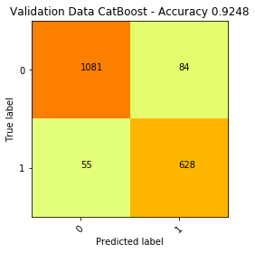

```python
plot_cm(y_pred_CatBoost, y_test, 'CatBoost')
```

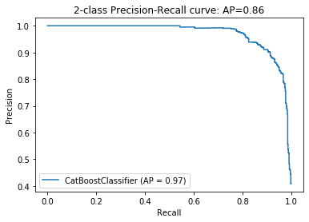

```python
plot_prc(classifier_CatBoost, X_test, y_test, y_pred_CatBoost)
```

```python
from sklearn.metrics import roc_auc_score
roc_auc_score(y_test, y_pred_CatBoost)
```

```
0.916803489476183
```

**Take a look at the feature importance**

```python
featureImp = []
for feat, importance in zip(X.columns, classifier_CatBoost.feature_importances_):
    temp = [feat, importance]
    featureImp.append(temp)

fT_df = pd.DataFrame(featureImp, columns = ['Feature', 'Importance'])
fT_df.sort_values('Importance', ascending = False).head(15)
```

|  | Feature | Importance |
| --- | --- | --- |
| 54 | Tags_Will revert after reading the email | 16.72 |
| 1 | TotalTime | 9.97 |
| 53 | Tags_Ringing | 8.59 |
| 21 | Last Activity_SMS Sent | 6.41 |
| 42 | CurrentOccupation_Unemployed | 5.19 |
| 4 | Lead Origin_Lead Add Form | 4.19 |
| 52 | Tags_Others | 4.10 |
| 61 | Lead Quality_Worst | 3.69 |
| 47 | Tags_Insterested | 3.64 |
| 0 | TotalVisits | 3.46 |
| 2 | PPV | 3.10 |
| 44 | Tags_Current Student | 3.09 |
| 49 | Tags_Lost | 2.38 |
| 60 | Lead Quality_Others | 2.16 |
| 16 | Last Activity_Email Opened | 1.84 |

### 4.12 K-Fold Cross Validation

```python
from sklearn.model_selection import cross_val_score
accuracies = cross_val_score(estimator = classifier_CatBoost, X = X_train, y = y_train, cv = 10)
```

```python
print("Accuracy: {:.2f} %".format(accuracies.mean()*100))
print("Standard Deviation: {:.2f} %".format(accuracies.std()*100))
```

```
Accuracy: 92.98 %
Standard Deviation: 0.84 %
```